# Regression

## Exercise 1: Linear Regression

*Are a person’s brain size and body size predictive of his or her intelligence?*

Interested in answering the above research question, some researchers (Willerman, et al, 1991) collected the following data (iqsize.txt) on a sample of n = 38 college students:

- *Response (y)*: Performance IQ scores (PIQ) from the revised Wechsler Adult Intelligence Scale. This variable served as the investigator’s measure of the individual’s intelligence.
- *Potential predictor (x1)*: Brain size based on the count obtained from MRI scans (given as count/10000).
- *Potential predictor (x2)*: Height in inches.
- *Potential predictor (x3)*: Weight in pounds.
1. Visualize the data appropriately (Hint: use the function plot() or pairs(), use the help-function, to find out how to implement it).

For more advance scatter plots, review https://www.statmethods.net/graphs/scatterplot.html

2. Describe the output from (a). What appears to be a good predictor?

PIQ is the best correlated with Brain and negatively with Height

3. Write down the model equation.

$$\begin{equation*}
y_i=\beta_0+\beta_1Brain_i+\beta_2Height_i+\beta_3Weight_i+\epsilon
\end{equation*}$$

4. Implement the model in R.
5. Interpret the model output.

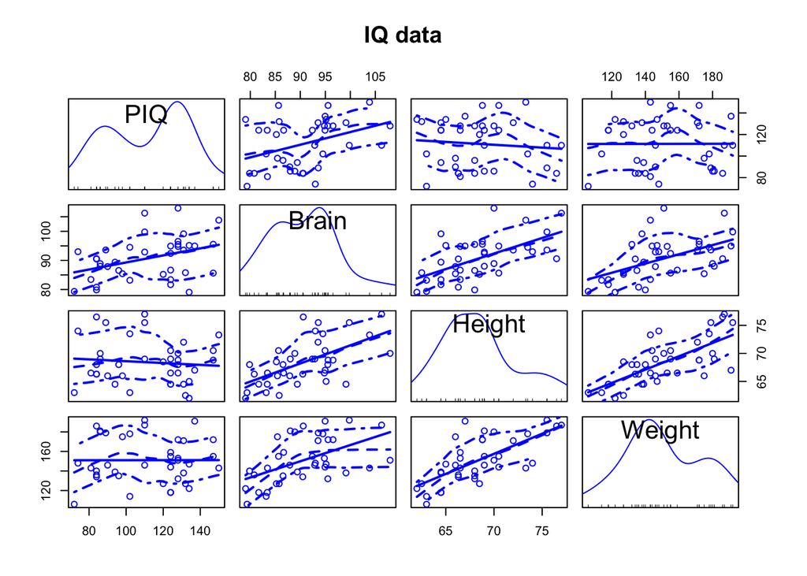

```r
f<-'iqsize.txt'
con <- file(f, "r")
header <- readLines(con, n=1)
close(con)
iq_data <- read.table(f, header=FALSE, skip=1)   # skip the first line
names(iq_data) <- strsplit(header, "\\s+")[[1]]

scatterplotMatrix(~PIQ+Brain+Height+Weight, data=iq_data, main="IQ data")
```

```r
#pairs(iq_data,upper.panel=panel.cor,diag.panel=panel.hist)

fitBP <- lm(formula = PIQ ~ Brain, data = iq_data)
#Intercept check how far it is from 0
summary(fitBP)
```

```
##
## Call:
## lm(formula = PIQ ~ Brain, data = iq_data)
##
## Residuals:
##     Min      1Q  Median      3Q     Max
## -40.077 -17.508  -2.095  17.097  41.571
##
## Coefficients:
##             Estimate Std. Error t value Pr(>|t|)
## (Intercept)   4.6519    43.7118   0.106   0.9158
## Brain         1.1766     0.4806   2.448   0.0194 *
## ---
## Signif. codes:  0 '***' 0.001 '**' 0.01 '*' 0.05 '.' 0.1 ' ' 1
##
## Residual standard error: 21.21 on 36 degrees of freedom
## Multiple R-squared:  0.1427, Adjusted R-squared:  0.1189
## F-statistic: 5.994 on 1 and 36 DF,  p-value: 0.01935
```

```r
fitall <- lm(formula = PIQ ~ Brain+Height+Weight, data = iq_data)
summary(fitall)
```

```
##
## Call:
## lm(formula = PIQ ~ Brain + Height + Weight, data = iq_data)
##
## Residuals:
##    Min     1Q Median     3Q    Max
## -32.74 -12.09  -3.84  14.17  51.69
##
## Coefficients:
##               Estimate Std. Error t value Pr(>|t|)
## (Intercept)  1.114e+02  6.297e+01   1.768 0.085979 .
## Brain        2.060e+00  5.634e-01   3.657 0.000856 ***
## Height      -2.732e+00  1.229e+00  -2.222 0.033034 *
## Weight       5.599e-04  1.971e-01   0.003 0.997750
## ---
## Signif. codes:  0 '***' 0.001 '**' 0.01 '*' 0.05 '.' 0.1 ' ' 1
##
## Residual standard error: 19.79 on 34 degrees of freedom
## Multiple R-squared:  0.2949, Adjusted R-squared:  0.2327
## F-statistic: 4.741 on 3 and 34 DF,  p-value: 0.007215
```

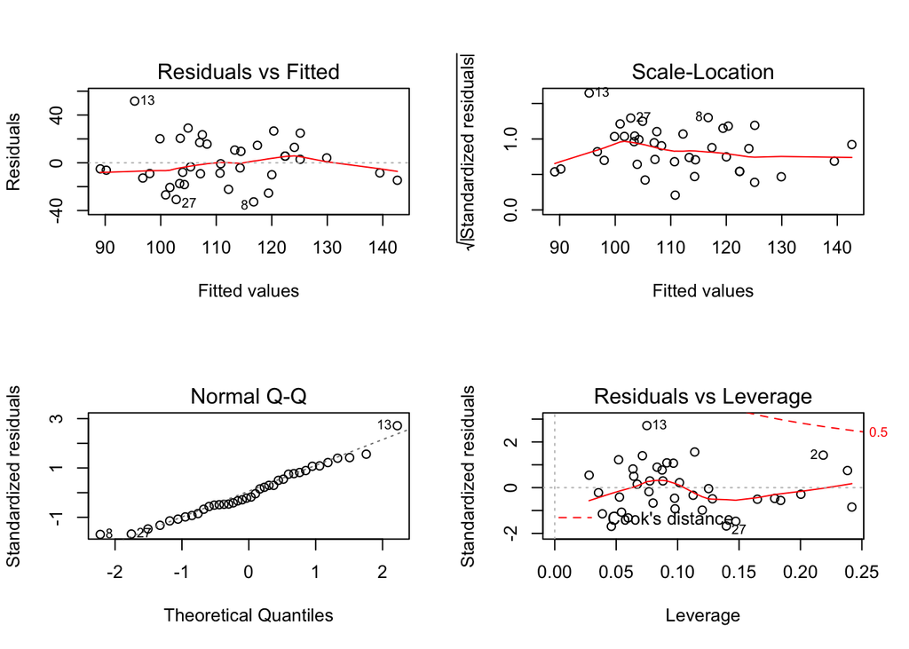

```r
layout(matrix(c(1,2,3,4),2,2)) # optional 4 graphs/page
plot(fitall)
```

```r
fitBPH <- lm(formula = PIQ ~ Brain+Height, data = iq_data)
summary(fitBPH)
```

```
##
## Call:
## lm(formula = PIQ ~ Brain + Height, data = iq_data)
##
## Residuals:
##     Min      1Q  Median      3Q     Max
## -32.750 -12.090  -3.841  14.174  51.690
##
## Coefficients:
##             Estimate Std. Error t value Pr(>|t|)
## (Intercept) 111.2757    55.8673   1.992 0.054243 .
## Brain         2.0606     0.5466   3.770 0.000604 ***
## Height       -2.7299     0.9932  -2.749 0.009399 **
## ---
## Signif. codes:  0 '***' 0.001 '**' 0.01 '*' 0.05 '.' 0.1 ' ' 1
##
## Residual standard error: 19.51 on 35 degrees of freedom
## Multiple R-squared:  0.2949, Adjusted R-squared:  0.2546
## F-statistic: 7.321 on 2 and 35 DF,  p-value: 0.002208
```

## Exercise 2: Multiple Linear Regression

*Problem Statement*: The Central Bank prints paper money each year. For each year they need an estimate of how much money to be printed. The decision is based on various economic indicators like GDP, Interest rate etc. We will try to model the solution to this problem using Multiple linear regression based on the data (demandmoney.csv).

- Get insight into the data by using the R-function str().
- Summarize the variables separately. Which approach would you use (there are several)?
- Identify the explanatory variables and the response variable.

Response = Money.printed

Explanatory = GDP and WPI

### These are timeseries, dependent on each other

- Compute a scatter plot of the variables. Describe how the covariates seem to be associated with the response variable.
- Construct a Linear model using R.
- Interpret the model output. Write down the model equation with the estimated parameters.

Money.printed = -2.798e+05 + 6.549e-01*GDP -3.624e+03*WPI

Monitor R-squared adjusted, where it peaks - there is good number of predictors

```r
money <- read.csv("demandmoney.csv")
#str(money)
summary(money)
```

```
##       year      Money.printed         GDP          Interest.RATE
##  Min.   :1970   Min.   :  7374   Min.   : 474131   Min.   : 5.375
##  1st Qu.:1978   1st Qu.: 18646   1st Qu.: 615406   1st Qu.: 9.000
##  Median :1987   Median : 58555   Median : 880267   Median :10.000
##  Mean   :1987   Mean   :146642   Mean   :1079314   Mean   : 9.786
##  3rd Qu.:1996   3rd Qu.:227725   3rd Qu.:1452676   3rd Qu.:11.000
##  Max.   :2004   Max.   :647495   Max.   :2389660   Max.   :13.000
##       WPI
##  Min.   : 14.30
##  1st Qu.: 28.90
##  Median : 58.20
##  Mean   : 77.37
##  3rd Qu.:124.40
##  Max.   :187.30
```

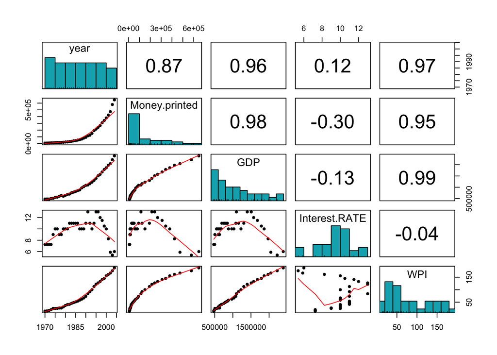

```r
pairs.panels(money,
             method = "pearson",hist.col = "#00AFBB",density = F,ellipses = F)
```

```r
fit <- lm(Money.printed~GDP+WPI, data = money)
summary(fit)
```

```
##
## Call:
## lm(formula = Money.printed ~ GDP + WPI, data = money)
##
## Residuals:
##    Min     1Q Median     3Q    Max
## -70695 -20153   -437  22582  52093
##
## Coefficients:
##               Estimate Std. Error t value Pr(>|t|)
## (Intercept) -2.798e+05  2.549e+04 -10.977 2.21e-12 ***
## GDP          6.549e-01  8.358e-02   7.836 6.12e-09 ***
## WPI         -3.624e+03  8.657e+02  -4.186 0.000207 ***
## ---
## Signif. codes:  0 '***' 0.001 '**' 0.01 '*' 0.05 '.' 0.1 ' ' 1
##
## Residual standard error: 31710 on 32 degrees of freedom
## Multiple R-squared:  0.9696, Adjusted R-squared:  0.9677
## F-statistic: 510.8 on 2 and 32 DF,  p-value: < 2.2e-16
```

```r
fitNonredundant <- lm(Money.printed~GDP, data = money)
summary(fitNonredundant)
```

```
##
## Call:
## lm(formula = Money.printed ~ GDP, data = money)
##
## Residuals:
##    Min     1Q Median     3Q    Max
## -55059 -28179  -8351  29258  98025
##
## Coefficients:
##               Estimate Std. Error t value Pr(>|t|)
## (Intercept) -1.852e+05  1.441e+04  -12.85 2.16e-14 ***
## GDP          3.074e-01  1.189e-02   25.86  < 2e-16 ***
## ---
## Signif. codes:  0 '***' 0.001 '**' 0.01 '*' 0.05 '.' 0.1 ' ' 1
##
## Residual standard error: 38840 on 33 degrees of freedom
## Multiple R-squared:  0.953,  Adjusted R-squared:  0.9516
## F-statistic:   669 on 1 and 33 DF,  p-value: < 2.2e-16
```

## Exercise 3: Generalized Linear Regression

Consider data published on n = 27 leukemia patients. The data (leukemiaremission.txt) has a response variable of whether leukemia remission occurred (REMISS), which is given by a 1.

The predictor variables are cellularity of the marrow clot section (CELL), smear differential percentage of blasts (SMEAR), percentage of absolute marrow leukemia cell infiltrate (INFIL), percentage labeling index of the bone marrow leukemia cells (LI), absolute number of blasts in the peripheral blood (BLAST), and the highest temperature prior to start of treatment (TEMP).

- Consider the response and explanatory variables and give the appropriate random and systematic component and the link function.

response: REMISS (random - binary)

explanatory: others (systematic)

link: logit

- Implement the model in R and interpret the model output.
- Give the estimated odds of leukemia remission for LI = 0.9.
- Compute the 95% Confidence intervals for the estimate for the predictor SMEAR.

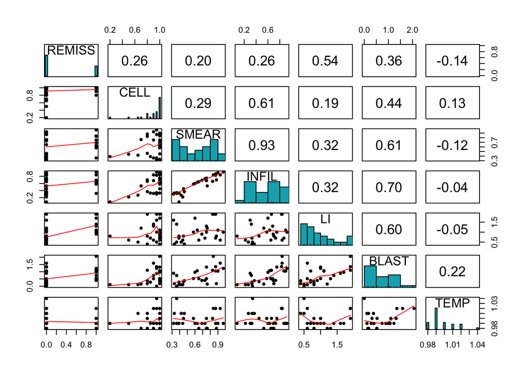

```r
f<-'leukemiaremission.txt'
con <- file(f, "r")
header <- readLines(con, n=1)
close(con)
leu_data <- read.table(f, header=FALSE, skip=1)   # skip the first line
names(leu_data) <- strsplit(header, "\\s+")[[1]]

pairs.panels(leu_data,
             method = "pearson",hist.col = "#00AFBB",density = F,ellipses = F)
```

```r
fit <- glm(REMISS~CELL+SMEAR+INFIL+LI+TEMP, family=binomial(link = "logit"), data=leu_data)
summary(fit)
```

```
##
## Call:
## glm(formula = REMISS ~ CELL + SMEAR + INFIL + LI + TEMP, family = binomial(link = "logit"),
##     data = leu_data)
##
## Deviance Residuals:
##      Min        1Q    Median        3Q       Max
## -1.95491  -0.66295  -0.02511   0.78223   1.57573
##
## Coefficients:
##             Estimate Std. Error z value Pr(>|z|)
## (Intercept)   64.308     74.318   0.865   0.3869
## CELL          30.862     51.752   0.596   0.5509
## SMEAR         24.752     60.135   0.412   0.6806
## INFIL        -25.056     63.288  -0.396   0.6922
## LI             4.353      2.210   1.970   0.0488 *
## TEMP        -100.247     76.374  -1.313   0.1893
## ---
## Signif. codes:  0 '***' 0.001 '**' 0.01 '*' 0.05 '.' 0.1 ' ' 1
##
## (Dispersion parameter for binomial family taken to be 1)
##
##     Null deviance: 34.372  on 26  degrees of freedom
## Residual deviance: 21.594  on 21  degrees of freedom
## AIC: 33.594
##
## Number of Fisher Scoring iterations: 8
```

```r
LI=0.9
remissP=exp(64.308 + 30.862+24.752-25.056+4.353*LI-100.247)
sprintf("Remission odds if LI is %0.2f is %0.2f",LI,remissP)
```

```
## [1] "Remission odds if LI is 0.90 is 0.23"
```

```r
sprintf("Conf interval for SMEAR is exp^ 24.75 +- %0.2f",60.135*1.95)
```

```
## [1] "Conf interval for SMEAR is exp^ 24.75 +- 117.26"
```

```r
fit <- glm(REMISS~LI, family=binomial(link = "logit"), data=leu_data)
summary(fit)
```

```
##
## Call:
## glm(formula = REMISS ~ LI, family = binomial(link = "logit"),
##     data = leu_data)
##
## Deviance Residuals:
##     Min       1Q   Median       3Q      Max
## -1.9448  -0.6465  -0.4947   0.6571   1.6971
##
## Coefficients:
##             Estimate Std. Error z value Pr(>|z|)
## (Intercept)   -3.777      1.379  -2.740  0.00615 **
## LI             2.897      1.187   2.441  0.01464 *
## ---
## Signif. codes:  0 '***' 0.001 '**' 0.01 '*' 0.05 '.' 0.1 ' ' 1
##
## (Dispersion parameter for binomial family taken to be 1)
##
##     Null deviance: 34.372  on 26  degrees of freedom
## Residual deviance: 26.073  on 25  degrees of freedom
## AIC: 30.073
##
## Number of Fisher Scoring iterations: 4
```

```r
LI=0.9
remissP=exp(-3.777 + 2.897*LI)
sprintf("Remission odds if LI is %0.2f is %0.2f",LI,remissP)
```

```
## [1] "Remission odds if LI is 0.90 is 0.31"
```